# Admixture in 2L

#### Introgression in the inverted background (`2`)

Now, let's see if the minority 296G-2La haplotype also has signals of introgression:

- A are inverted gams in 296G cluster ("GHgam_2","GNgam_2","CMgam_2")
- B is a gam not in cluster and inverted (UGgam_2)
- C are various cols, some in cluster ("CIcol_2","GHcol_2") and some not ("BFcol_2")
- D are non-inverted outgroups: meru, epir, chri; arab is not good because of independent introgression with BFcol_2

This demonstrates that there was **no introgression of 296G between gambiae and coluzzi in the inverted background**.

```
(((BFgam_2,UGgam_2),X),meru_2) chr
(((CMgam_2,UGgam_2),X),meru_2) chr
(((GHgam_2,UGgam_2),X),meru_2) chr
(((GNgam_2,UGgam_2),X),meru_2) chr
(((BFgam_2,UGgam_2),X),epir_2) chr
(((CMgam_2,UGgam_2),X),epir_2) chr
(((GHgam_2,UGgam_2),X),epir_2) chr
(((GNgam_2,UGgam_2),X),epir_2) chr
(((BFgam_2,UGgam_2),X),chri_2) chr
(((CMgam_2,UGgam_2),X),chri_2) chr
(((GHgam_2,UGgam_2),X),chri_2) chr
(((GNgam_2,UGgam_2),X),chri_2) chr
(((BFgam_2,UGgam_2),X),arab_2) chr
(((CMgam_2,UGgam_2),X),arab_2) chr
(((GHgam_2,UGgam_2),X),arab_2) chr
(((GNgam_2,UGgam_2),X),arab_2) chr
```

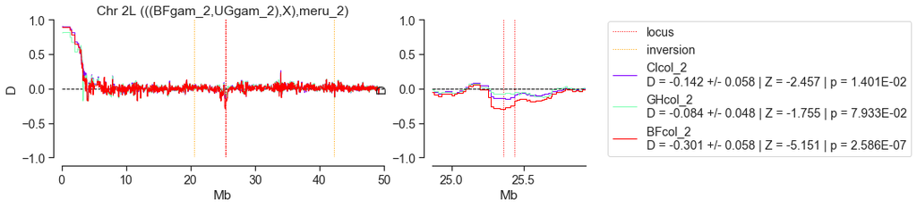

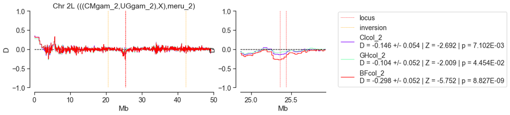

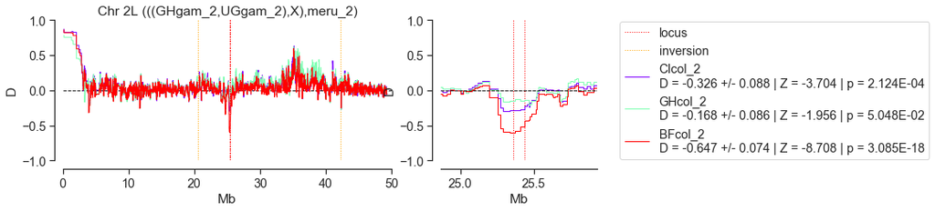

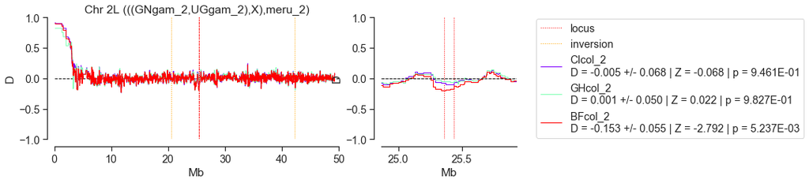

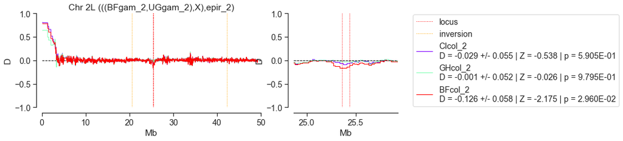

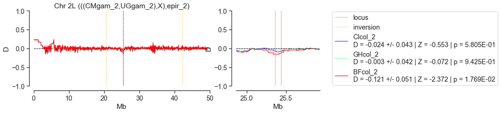

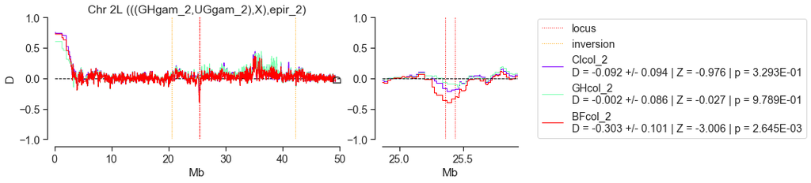

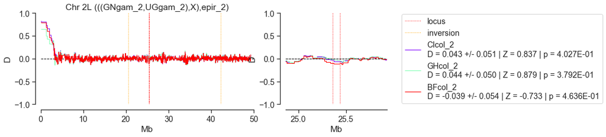

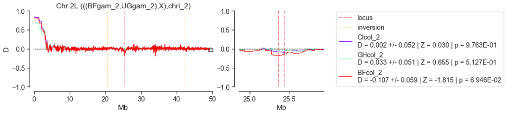

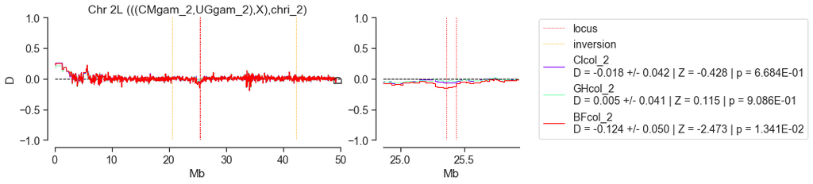

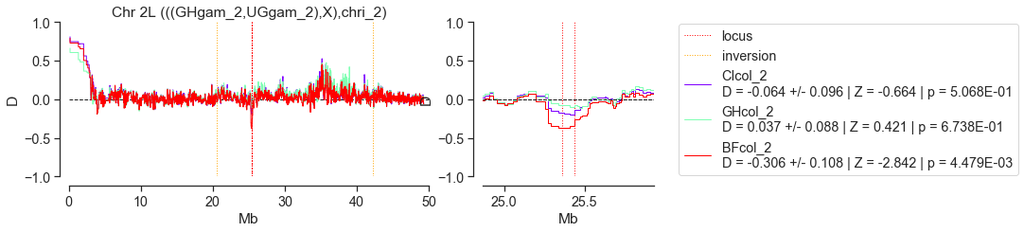

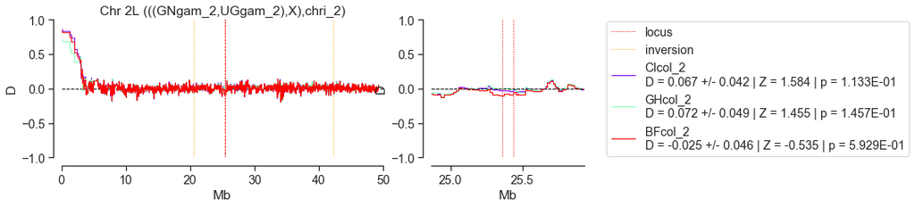

[4 more figures not shown]

```python
%%capture --no-stdout --no-display
loop_D_statistic3(
    name="colgam_clu296G_back2_ABgam_Ccol",
    popA_list=["BFgam_2","CMgam_2","GHgam_2","GNgam_2"],
    popB_list=["UGgam_2"],
    popC_list=["CIcol_2","GHcol_2","BFcol_2"],
    popD_list=["meru_2","epir_2","chri_2","arab_2"],
    popA_ac=oc_genalco_pop_seg_inv,
    popB_ac=oc_genalco_pop_seg_inv,
    popC_ac=oc_genalco_pop_seg_inv,
    popD_ac=oc_genalco_sps_seg_inv,
    pos=oc_genvars_seg["POS"][:],
    cycle="C"
)
```

#### Plot transcripts in region of interest

Finally, plot the coordinates of transcripts in the region of interest, so that you can create nice-looking plots:

```python
pdf = PdfPages("%s/%s.genes.pdf" % (outdir,outcode))
# plot transcripts
fig = plt.figure(figsize=(15,1))
ax4 = plt.subplot(1, 4, 3)
sns.despine(ax=ax4,offset=10)
locus_genel = plot_transcripts(
    geneset=geneset,chrom=chrom,
    start=loc_start-5e5,stop=loc_end+5e5,
    height=0.1,label_transcripts=False,ax=ax4,label_axis=False,
    color="slategray")

pdf.savefig(fig,bbox_inches='tight')
pdf.close()
```

## Differentiation

Calculate Hudson's $F_{ST}$ along the entire 2L chromosomal arm, to see if there is a drop in differentiation between non-concordant karyotypes at the center of the 2La inversion.

First, a loop function.

```python
def loop_Fst(name, popA_list, popC_list,
             popA_ac, popC_ac,
             pos,cycle = "C", block_len_snp=block_len_snp, step_len_snp=step_len_snp,
             color=["blue","darkorange","turquoise","crimson","magenta","limegreen",
                    "forestgreen","slategray","orchid","darkblue"]):

    windows_pos = allel.stats.moving_statistic(pos, statistic=lambda v: v[0], size=block_len_snp,step=step_len_snp)

    # calculate pvalues and focus in this region: duplicated region proper
    is_locus = np.logical_and(pos > loc_start,pos < loc_end) # gene region
    is_inv   = np.logical_and(pos > inv_start,pos < inv_end) # inversion region

    # loop
    pdf = PdfPages("%s/%s.Fst_%s.pdf" % (outdir,outcode,name))

    colors = cm.rainbow(np.linspace(0, 1, len(popC_list)))

    for an,popA in enumerate(popA_list):

        fig = plt.figure(figsize=(15,3))

        # whole chromosome: frame
        ax1 = plt.subplot(1, 2, 1)
        sns.despine(ax=ax1,offset=10)
        ax1.set_title("Chr %s Fst %s~X" % (chrom,popA))
        ax1.set_xlim(0,50)
        ax1.set_ylim(0,1)
        ax1.set_xlabel("Mb")
        ax1.set_ylabel("Fst")
        plt.axhline(0, color='k',linestyle="--",label="")
        plt.axvline(loc_start/1e6, color='red',linestyle=":",label="locus")
        plt.axvline(loc_end/1e6, color='red',linestyle=":",label="")
        plt.axvline(inv_start/1e6, color='orange',linestyle=":",label="inversion")
        plt.axvline(inv_end/1e6, color='orange',linestyle=":",label="")

        ax2 = plt.subplot(1, 4, 3)
        sns.despine(ax=ax2,offset=10)
        ax2.set_xlim(loc_start/1e6-0.5,loc_end/1e6+0.5)
        ax2.set_ylim(0,1)
        ax2.set_xlabel("Mb")
        ax2.set_ylabel("Fst")
        plt.axhline(0, color='k',linestyle="--",label="")
        plt.axvline(loc_start/1e6, color='red',linestyle=":",label="locus")
        plt.axvline(loc_end/1e6, color='red',linestyle=":",label="")
        plt.axvline(inv_start/1e6, color='orange',linestyle=":",label="inversion")
        plt.axvline(inv_end/1e6, color='orange',linestyle=":",label="")

        for cn,popC in enumerate(popC_list):

            if popA != popC:

                # block-wise patterson D (normalised)
                admix_pd_n_win = allel.moving_hudson_fst(
                    ac1=popA_ac[popA][:,0:2],
                    ac2=popC_ac[popC][:,0:2],
                    size=block_len_snp,step=step_len_snp)

                # whole chromosome: plot
                plt.subplot(1, 2, 1)
                plt.step(windows_pos/1e6, admix_pd_n_win, color=colors[cn])

                # estimated D in locus with pval
                admix_pd_av_indup = allel.average_hudson_fst(
                    ac1=popA_ac[popA][:,0:2][is_locus],
                    ac2=popC_ac[popC][:,0:2][is_locus],
                    blen=100)
                # zoomed region: plot
                plt.subplot(1, 4, 3)
                plt.step(windows_pos/1e6, admix_pd_n_win, color=colors[cn],
                         label="%s\nFst = %.3f +/- %.3f" %
                             (popC,admix_pd_av_indup[0],admix_pd_av_indup[1]))

        plt.axhline(0, color='k',linestyle="--",label="")
        ax2.legend(loc='center left', bbox_to_anchor=(1.1, 0.5))

        # save pdf
        pdf.savefig(fig,bbox_inches='tight')

    pdf.close()
```

Plot differentiation between specimens grouped by species and karyotype:

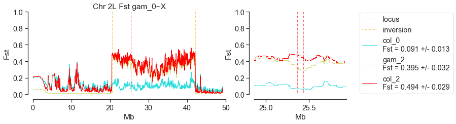

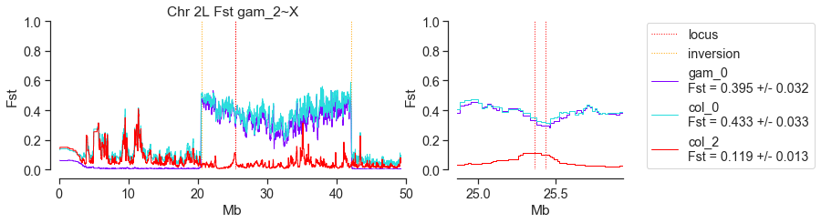

```python
%%capture --no-stdout --no-display
loop_Fst(
    name="colgaminv",
    popA_list=["gam_0","gam_2"],
    popC_list=["gam_0","col_0","gam_2","col_2"],
    popA_ac=oc_genalco_sps_seg_inv,
    popC_ac=oc_genalco_sps_seg_inv,
    pos=oc_genvars_seg["POS"][:],
    cycle="C"
)
```